# Reproducible Research: Peer Assessment 1

Alpatov

19 april 2018 г

## Loading and preprocessing the data

Load the data and read data (R code):

```r
fileUrl <- "https://d396qusza40orc.cloudfront.net/repdata%2Fdata%2Factivity.zip"
download.file(fileUrl, destfile = paste0(getwd(), '/repdata%2Fdata%2Factivity.zip'))
unzip("repdata%2Fdata%2Factivity.zip",exdir = "activ")
data_activ<-read.csv(file = "activ/activity.csv")
```

## What is mean total number of steps taken per day?

Calculate the total number of steps taken per day

```r
steps<- tapply(data_activ$steps, data_activ$date, "sum", na.rm = TRUE)
```

Histogram and a barplot

Histogram

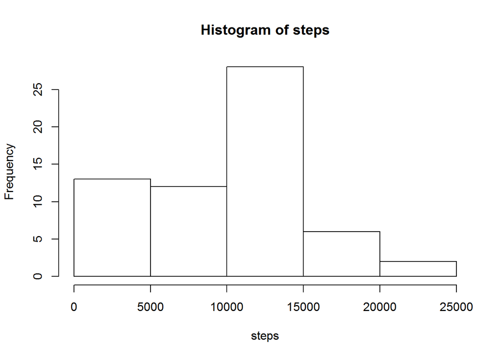

```r
hist(steps)
```

Barplot

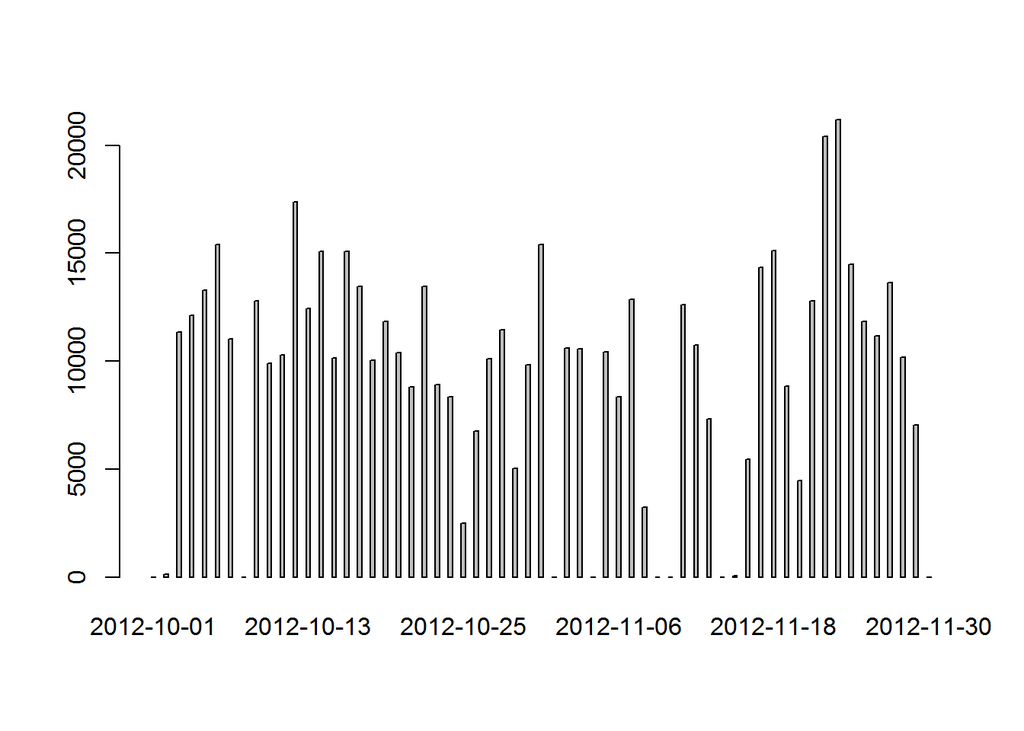

```r
barplot(height = steps,space = 2)
```

Calculate the mean and median of the total number of steps taken per day

```r
mean(steps)
```

```
## [1] 9354.23
```

```r
median(steps)
```

```
## [1] 10395
```

## What is the average daily activity pattern?

Time series plot of the 5-minute interval (x-axis) and the average number of steps taken, averaged across all days (y-axis)

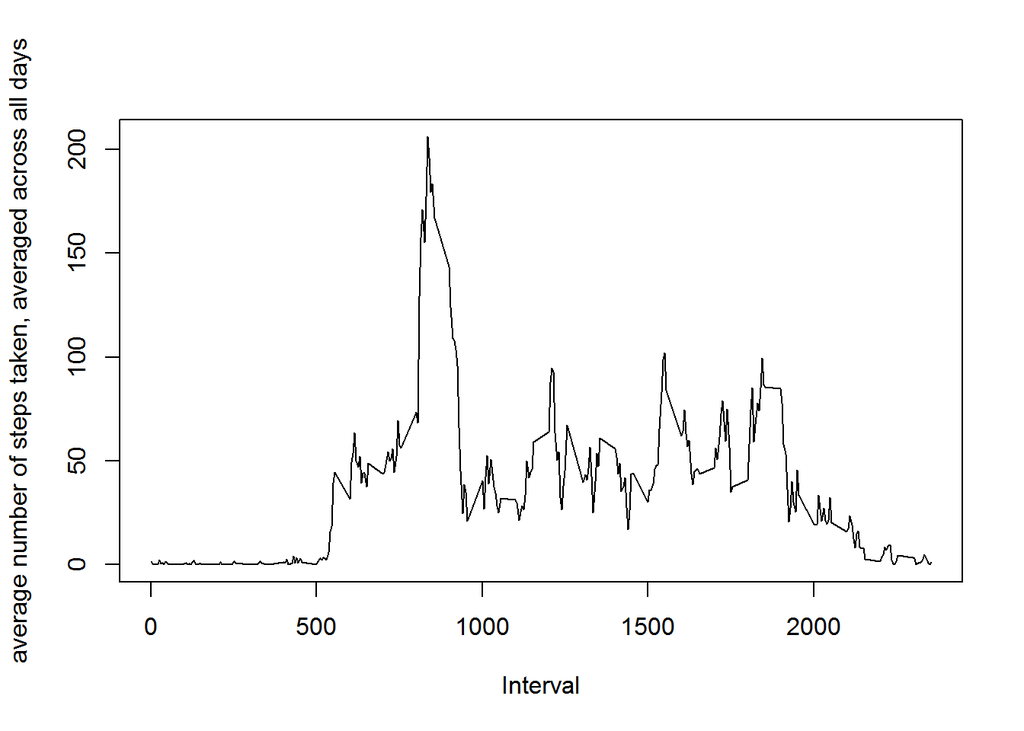

```r
pl_Step<-tapply(data_activ$steps, data_activ$interval, "mean", na.rm = TRUE)
plot(names(pl_Step), pl_Step, type = "l",xlab="Interval", ylab="average number of steps taken, averaged across all days")
```

Which 5-minute interval, on average across all the days in the dataset, contains the maximum number of steps?

```r
x<-max.col(t(pl_Step),"last")
pl_Step[x]
```

```
##      835
## 206.1698
```

## Imputing missing values

Calculate the total number of missing values in the dataset

```r
sum(is.na(data_activ))
```

```
## [1] 2304
```

```r
sum(is.na(data_activ$steps))
```

```
## [1] 2304
```

```r
sum(is.na(data_activ$interval))
```

```
## [1] 0
```

```r
sum(is.na(data_activ$date))
```

```
## [1] 0
```

Strategy for filling in all of the missing values in the dataset. Create a new dataset.

```r
na_mean<-mean(data_activ$steps, na.rm = TRUE)
data_activ[is.na(data_activ)]<-na_mean
```

Make a histogram of the total number of steps taken each day and Calculate and report the mean and median total number of steps taken per day.

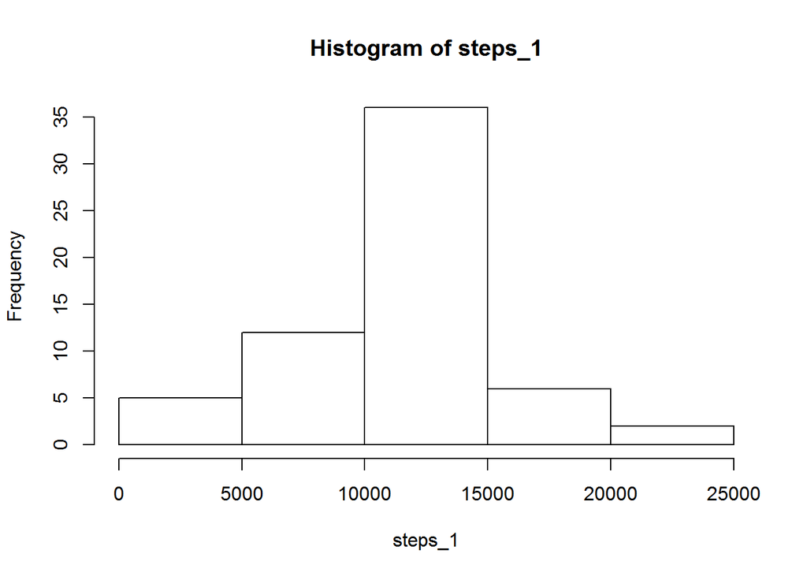

```r
steps_1<- tapply(data_activ$steps, data_activ$date, "sum", na.rm = TRUE)
hist(steps_1)
```

```r
mean(steps_1)
```

```
## [1] 10766.19
```

```r
median(steps_1)
```

```
## [1] 10766.19
```

```r
mean(steps)
```

```
## [1] 9354.23
```

```r
median(steps)
```

```
## [1] 10395
```

## Are there differences in activity patterns between weekdays and weekends?

Create a new factor variable in the dataset with two levels – “weekday” and “weekend” indicating whether a given date is a weekday or weekend day.

```r
Sys.setlocale("LC_TIME", "English")
```

```
## [1] "English_United States.1252"
```

```r
data_activ['day'] <- weekdays(as.Date(data_activ$date))
data_activ$day[data_activ$day  %in% c('Saturday','Sunday') ] <- "weekend"
data_activ$day[data_activ$day  %in% c('Monday','Tuesday','Wednesday','Thursday','Friday') ] <- "weekday"
data_step <- aggregate(steps ~ interval + day, data_activ, mean)
```

Make a panel plot containing a time series plot (i.e. type = “l”) of the 5-minute interval (x-axis) and the average number of steps taken, averaged across all weekday days or weekend days (y-axis). See the README file in the GitHub repository to see an example of what this plot should look like using simulated data.

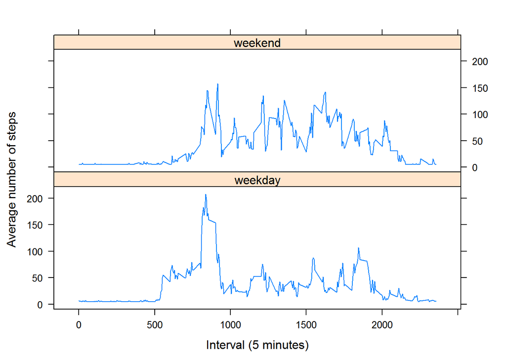

```r
library(lattice)
xyplot(steps ~ interval | day, data_step,  type = "l", layout = c(1,2), xlab = "Interval (5 minutes)", ylab = "Average number of steps")
```